# ¶ *“S7 Investigación sobre la percepción de la 3° dosis”* ¶

## Altura

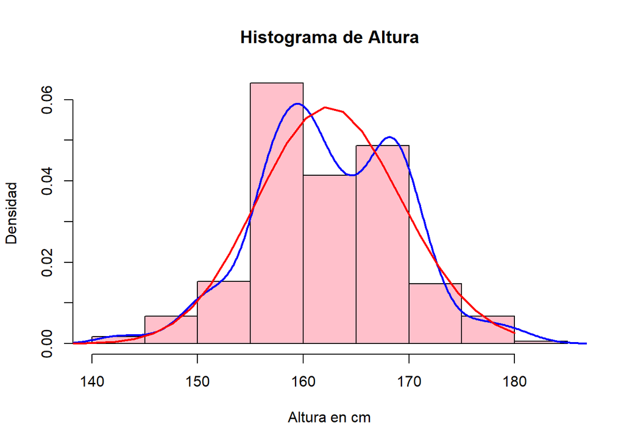

```r
x <- DFN$Altura
dx<- density(x)
model<-fitdist(x, "gamma")
a=model$estimate[1]
b=model$estimate[2]
h<-hist(DFN$Altura,breaks=10, freq=FALSE, main="Histograma de Altura", ylab="Densidad" ,xlab="Altura en cm", col="pink")
lines(dx, lwd = 2, col = "blue")
curve(dgamma(x,a,b),from=0,to=180,col="red",lwd=2,add=T)
```

```r
summary(DFN$Altura)
```

```
##    Min. 1st Qu.  Median    Mean 3rd Qu.    Max.
##   142.0   158.0   162.0   162.6   168.0   182.0
```

```r
round(sd(DFN$Altura, na.rm=TRUE),digits=2)               #DESVIACIÓN ESTANDAR
```

```
## [1] 6.85
```

```r
# El valor de la desviación estándar para esta variable es 6,85, entonces la variabilidad de las alturas es moderado.

cv <-(sd(DFN$Altura, na.rm = TRUE)/mean(DFN$Altura, na.rm = TRUE))# Coeficiente de variación
round(cv,digits = 2)
```

```
## [1] 0.04
```

```r
# Su coeficiente de variación es 0.04, existe mayor homogeneidad en los datos y tenemos una muestra compacta
```

*Observaciones de la variable Altura*

- Apreciamos que la mayoría de los datos están concentrados entre 140 y 170.
- Los valores de la media, moda y mediana son parecidos, por lo cual la variable se distribuye de manera casi simétrica.
- Como el valor de la altura se distribuye de forma bimodal es por eso que no se distribuye exactamente igual a la curva observada.

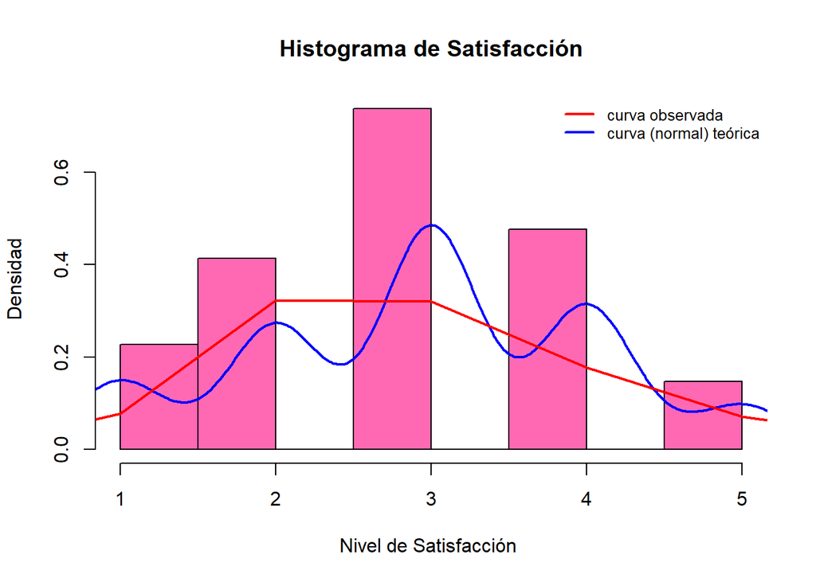

```r
x <- DFN$Satisfaccion
dx<- density(x)
model<-fitdist(x, "gamma")
a=model$estimate[1]
b=model$estimate[2]
h<-hist(DFN$Satisfaccion,breaks=10, freq=FALSE, main="Histograma de Satisfacción", ylab = "Densidad" ,xlab="Nivel de Satisfacción ", col="hotpink")
lines(dx, lwd = 2, col = "blue")
curve(dgamma(x,a,b),from=0,to=100,col="red",lwd=2,add=T)
legend("topright", c("curva observada", "curva (normal) teórica"),
       lty = 1, lwd = 2, col = c("red", "blue"), bty = "n",
       cex = 0.8)
```